[Home](https://rcap107.github.io/) » [Main Subjects](https://rcap107.github.io/posts/) » [Playing with IoT devices](https://rcap107.github.io/posts/raspberry/)

# Studying the thermometer readings and playing with timeseries in Python

July 17, 2022 · 16 min · Riccardo Cappuzzo | [Suggest Changes](https://github.com/rcap107.github.io/content)

# Plotting temperature and humidity sensor readings with matplotlib

In this notebook, I will take a look at the readings from a DHT22 temperature-humidity sensor that I have left for a few days in a couple of locations in my house. As I'm writing this, we're in the middle of the summer and there's a heatwave going on, so the average temperatures will be *pretty high*.

By gathering data over the course of different days and by varying some conditions (e.g. opening certain windows), I'm hoping to find what's the best way of cooling down the house at night, and keeping it cool during the day.

### Libraries

Let's start by talking about the libraries. Nothing pretty fancy here. `pandas` is there to put all the log readings into a dataframe, `matplotlib` and `seaborn` are graph visualization libraries for plotting data and `datetime` is there because I am working with timeseries. `matplotlib.dates` is used to customize some of the plotting parameters when handling dates.

```python
import pandas as pd
import matplotlib.pyplot as plt
import seaborn as sns
import datetime
import matplotlib.dates as mdates
```

```python
from IPython.display import display, Markdown
# df is your pandas.DataFrame. to_markdown requires tabulate
# df_markdown = df.to_markdown(index=False)
# display(Markdown(df_markdown))
```

## Part 1: the attic

### Reading and cleaning the data

The temperature/humidity readings are stored in a csv file, together with the timestamp of the reading. Let's start with the readings coming from the sensor left in the attic.

```python
df = pd.read_csv('log.txt', header=0, names=['date','time', 'temperature', 'humidity'])
```

The next few commands are there for turning the datetime into a more manageable format, which helps with plotting later. In particular, since the `date` and `time` columns are read as strings, the following lines convert them back into datetime format.

Then, the two are combined back into a singular `datetime` object for each row, with the entire timestamp.

```python
df['time'] = df['time'].apply(datetime.time.fromisoformat)
df['date'] = df['date'].apply(datetime.date.fromisoformat)

df['datetime'] = pd.to_datetime([datetime.datetime.combine(a, b) for a,b in zip(df['date'], df['time'])])
```

Now that I have a unique `datetime` index for every row, I can reset the index of the dataframe so that it uses the timestamp, rather than the regular ID.

The next step is resampling the timeline in order to reduce the number of readings, and to reduce the effect of anomalous readings. In this example, readings are grouped every 30 minutes, then they are aggregated by using the `mean` function.

Out of curiosity, and following a procedure I am not completely sure of, I am trying to plot the variance of the measurement over the same interval of time by aggregating with `var`, then plotting using the `fill_between` function.

```python
# Resetting the index so that it uses the datetime, then aggregating according to mean and variance.
df_resampled = df.set_index('datetime').resample('30Min').mean()

df_var = df.set_index('datetime').resample('30Min').var()
```

Time for the first plots. Here, I am plotting all the readings from the moment I activated the process, to the moment I saved it on disk to study the readings. To better distinguish between days, I am searching for the timestamps with time `(0,0)` (i.e. midnight), then I'm saving them in the variable `midnight`.

The command `df_resampled.index.time==datetime.time(0,0)` looks in the `.time` attribute of the datetime objects in the index and checks if the value contained therein is the same as `datetime.time(0,0)`.

The first plot will show the timeseries of temperature and humidity, along with their (supposed) error bars. Since I'm using the same code for plotting both temperature and humidity, I wrote a simple function that takes as input the dataframe and the variable of interest, then prepares the resulting plot.

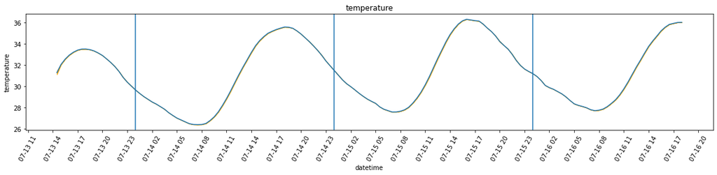

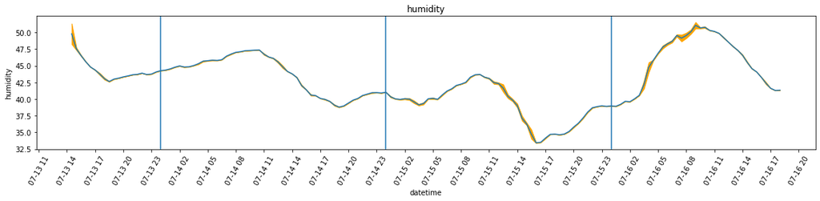

```python
def plot_overall_var(df, tgt_var, df_var=None):

    def get_bounds(df_base, df_var, column):
        '''Preparing the upper and lower bounds by adding the variance
        '''
        y1 = df_base[column] + df_var[column]
        y2 = df_base[column] - df_var[column]

        return y1,y2

    # Setting the size of the figure
    fig = plt.figure(figsize=(16,4))

    # Plotting the main line
    ax = sns.lineplot(x=df_resampled.index, y=df_resampled[tgt_var])
    plt.title(tgt_var)

    # If provided, adding the variance
    if df_var is not None:
        yhigh, ylow = get_bounds(df_resampled, df_var, tgt_var)
        plt.fill_between(df_resampled.index, ylow, yhigh, color='orange')

    # Plotting vertical lines for highlighting the change of date
    midnight = df_resampled.loc[df_resampled.index.time==datetime.time(0,0)].index
    for day in midnight:
        plt.axvline(day)

    # Plotting ticks every 3 hours
    _ = ax.xaxis.set_major_locator(mdates.HourLocator(interval=3))

    # Rotating the ticks
    ax.xaxis.set_tick_params(rotation=60)

    # Tightening the result
    plt.tight_layout()

plot_overall_var(df_resampled, 'temperature', df_var)
plot_overall_var(df_resampled, 'humidity', df_var)
```

### Plotting results by day

In the next section, I will reshape the data with the objective of comparing the readings gathered in different days, to look for potential similarities and differences. To do so, I'll first split the `datetime` index into columns `date` and `time`, then I will pivot the table so that the new index will be `time`, and the columns will report temperature and humidity for each day. As you'll notice, a bunch of values are missing and get with the value `NaN`: this is due to the fact that I started the data collection around 14h on July 13th.

```python
df_resampled['date'] = df_resampled.index.date
df_resampled['time'] = df_resampled.index.time

df_pivot=df_resampled.pivot(index='time', columns='date')
# Displaying only the first 10 rows
df_pivot.head(10)
df_markdown = df_pivot.head(10).to_markdown(index=True)
print(df_markdown)
# display(Markdown(df_markdown))
```

[output not shown]

Here I'm plotting the values of temperature and humidity recorded on each day.

```python
time_range = pd.timedelta_range(start='1 day', end='2 days', freq='3H')
```

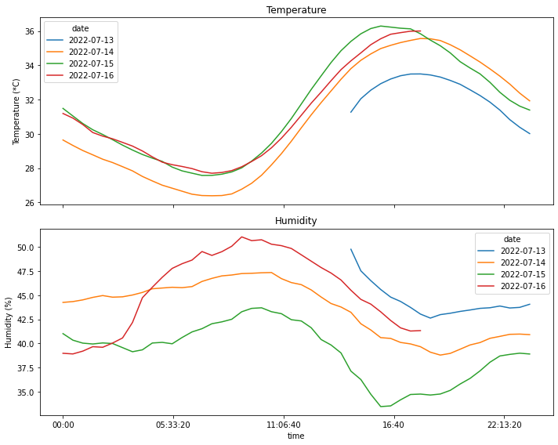

```python
fig, axs = plt.subplots(2,1, sharex=True, figsize=(10, 8))
df_pivot=df_resampled.pivot(index='time', columns='date')
a=df_pivot['temperature'].plot(title='Temperature', ylabel='Temperature (*C)', ax=axs[0], legend=True)

df_pivot=df_resampled.pivot(index='time', columns='date')
df_pivot['humidity'].plot(ax=axs[1], title='Humidity', ylabel='Humidity (%)', legend=True)

# plt.legend([a.lines])
plt.tight_layout()
plt.savefig('temp-humid-attic.png', transparent=False, facecolor='white')
```

### Finding the daily extremes

In this section, I will be parsing the data and look for the daily extremes (maximum and minimum) for temperature and humidity, and the time at which they occurred.

```python
# Simple dictionary for formatting the unit of measurement that will be printed
d_form = {'temperature': '*C', 'humidity': '%'}
```

```python
# Grouping by day
for idx, day_g in df_resampled.groupby('date'):
    print(f'Date: {idx}')

#     Maximum
#     idxmax returns the position of the maximum value
    aggr_i = day_g[['temperature', 'humidity']].aggregate(pd.Series.idxmax)
    aggr_m = day_g[['temperature', 'humidity']].aggregate(pd.Series.max)
#     Putting the values together for pretty printing
    df_t=pd.concat([aggr_i, aggr_m], axis=1)
    for i, val in df_t.iterrows():
        print(f'Max {i:>12} = {val[1]:.1f} {d_form[i]:>2} at {val[0].time()}')

#     Minimum
#     idxmax returns the position of the maximum value
    aggr_i = day_g[['temperature', 'humidity']].aggregate(pd.Series.idxmin)
    aggr_m = day_g[['temperature', 'humidity']].aggregate(pd.Series.min)
#     Putting the values together for pretty printing
    df_t=pd.concat([aggr_i, aggr_m], axis=1)
    for i, val in df_t.iterrows():
        print(f'Min {i:>12} = {val[1]:.1f} {d_form[i]:>2} at {val[0].time()}')
```

```
Date: 2022-07-13
Max  temperature = 33.5 *C at 18:00:00
Max     humidity = 49.8  % at 14:30:00
Min  temperature = 30.0 *C at 23:30:00
Min     humidity = 42.6  % at 18:30:00
Date: 2022-07-14
Max  temperature = 35.6 *C at 18:00:00
Max     humidity = 47.4  % at 10:30:00
Min  temperature = 26.4 *C at 07:30:00
Min     humidity = 38.8  % at 19:00:00
Date: 2022-07-15
Max  temperature = 36.3 *C at 16:00:00
Max     humidity = 43.7  % at 10:00:00
Min  temperature = 27.6 *C at 07:00:00
Min     humidity = 33.4  % at 16:00:00
Date: 2022-07-16
Max  temperature = 36.0 *C at 18:00:00
Max     humidity = 51.1  % at 09:00:00
Min  temperature = 27.7 *C at 07:30:00
Min     humidity = 38.9  % at 00:30:00
```

## Part 2: the bedroom

In this section, I will be repeating most of what was done in Part 1: the main difference will be the location of the sensor. Rather than keeping it in the attic, in fact, I was keeping this on the desk in my bedroom. In particular, the sensor was exposed to the heat coming from a pretty chonky desktop PC, as well as two monitors, and it is positioned close to a window.

```python
df = pd.read_csv('readings-room.csv', header=0, names=['date','time', 'temperature', 'humidity'])
```

```python
df['time'] = df['time'].apply(datetime.time.fromisoformat)
df['date'] = df['date'].apply(datetime.date.fromisoformat)

df['datetime'] = pd.to_datetime([datetime.datetime.combine(a, b) for a,b in zip(df['date'], df['time'])])
```

```python
# Resetting the index so that it uses the datetime, then aggregating according to mean and variance.
df_resampled = df.set_index('datetime').resample('30Min').mean()

df_var = df.set_index('datetime').resample('30Min').var()
```

Below, I'm plotting the overall temperature and humidity readings. Unlike in the case of the attic, however, the variance is far more larger, which leads to a plot that is almost unreadable in the case of humidity. For this reason, I am also plotting the graphs without added bands by calling `plot_overall_var` without the `df_var` variable.

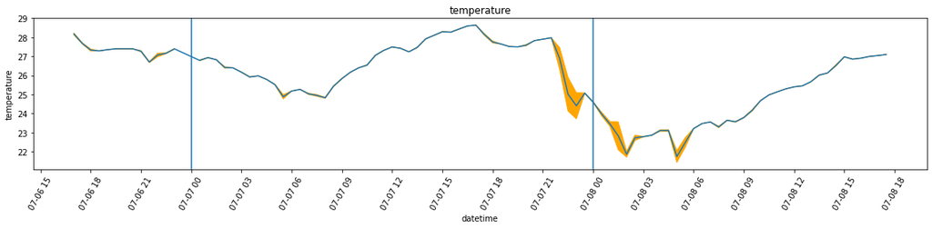

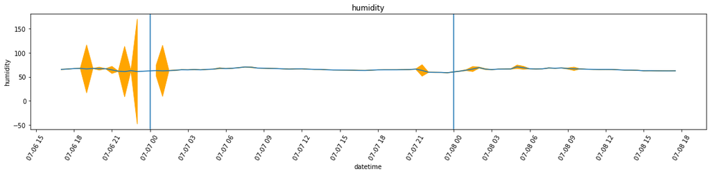

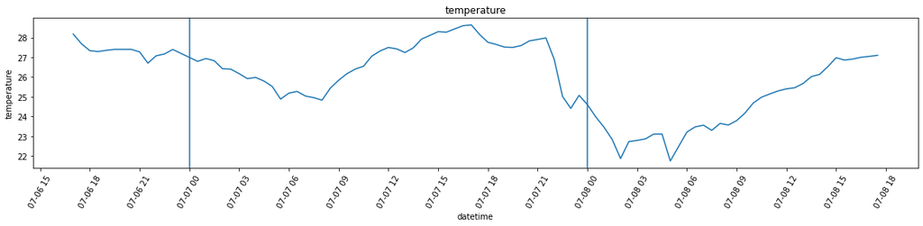

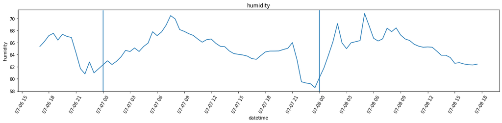

```python
plot_overall_var(df_resampled, 'temperature', df_var)
plot_overall_var(df_resampled, 'humidity', df_var)

plot_overall_var(df_resampled, 'temperature')
plot_overall_var(df_resampled, 'humidity')
```

### Plotting results by day

```python
df_resampled['date'] = df_resampled.index.date
df_resampled['time'] = df_resampled.index.time

df_pivot=df_resampled.pivot(index='time', columns='date')
# Displaying only the first 10 rows
df_pivot.head(10)
```

| date time | temperature 2022-07-06 | temperature 2022-07-07 | temperature 2022-07-08 | humidity 2022-07-06 | humidity 2022-07-07 | humidity 2022-07-08 |
| --- | --- | --- | --- | --- | --- | --- |
| 00:00:00 | NaN | NaN | 24.601786 | NaN | NaN | 60.225000 |
| 00:30:00 | NaN | 26.792857 | 23.985965 | NaN | 62.985715 | 61.821053 |
| 01:00:00 | NaN | 26.937255 | 23.458929 | NaN | 62.368627 | 63.941071 |
| 01:30:00 | NaN | 26.825000 | 22.831579 | NaN | 62.901786 | 66.178947 |
| 02:00:00 | NaN | 26.421053 | 21.867273 | NaN | 63.638596 | 69.143637 |
| 02:30:00 | NaN | 26.396428 | 22.728572 | NaN | 64.705357 | 65.946429 |
| 03:00:00 | NaN | 26.171930 | 22.787719 | NaN | 64.521053 | 64.991228 |
| 03:30:00 | NaN | 25.918965 | 22.864285 | NaN | 65.108621 | 65.960714 |
| 04:00:00 | NaN | 25.978571 | 23.108929 | NaN | 64.525000 | 66.139285 |
| 04:30:00 | NaN | 25.794736 | 23.110527 | NaN | 65.349123 | 66.324561 |

```python
val_idxmax=df_pivot[['temperature', 'humidity']].apply(pd.Series.idxmax)
val_max=df_pivot[['temperature', 'humidity']].apply(pd.Series.max)
```

```python
df_concat = pd.concat([val_idxmax, val_max],  axis=1).reset_index().pivot(index='date', columns='level_0')
df_concat
```

| level_0 date | 0 humidity | 0 temperature | 1 humidity | 1 temperature |
| --- | --- | --- | --- | --- |
| 2022-07-06 | 18:30:00 | 17:00:00 | 67.537736 | 28.174419 |
| 2022-07-07 | 07:30:00 | 17:00:00 | 70.470175 | 28.641072 |
| 2022-07-08 | 05:00:00 | 17:30:00 | 70.805263 | 27.100000 |

```python
mi = pd.MultiIndex.from_product([['humidity', 'temperature'], ['timeat', 'value']])
```

```python
rows=[]
for idx, row in df_concat.iterrows():
    t = [row[idx][variable]  for variable in ['humidity', 'temperature'] for idx in [0,1] ]
    rows.append([idx] + t)
```

```python
df_new = pd.DataFrame.from_records(rows)
df_new=df_new.set_index(0)
df_new.index.rename('date', inplace=True)
df_new.columns = mi
df_new
```

| date | humidity timeat | humidity value | temperature timeat | temperature value |
| --- | --- | --- | --- | --- |
| 2022-07-06 | 18:30:00 | 67.537736 | 17:00:00 | 28.174419 |
| 2022-07-07 | 07:30:00 | 70.470175 | 17:00:00 | 28.641072 |
| 2022-07-08 | 05:00:00 | 70.805263 | 17:30:00 | 27.100000 |

```python
time_range = pd.timedelta_range(start='1 day', end='2 days', freq='3H')
```

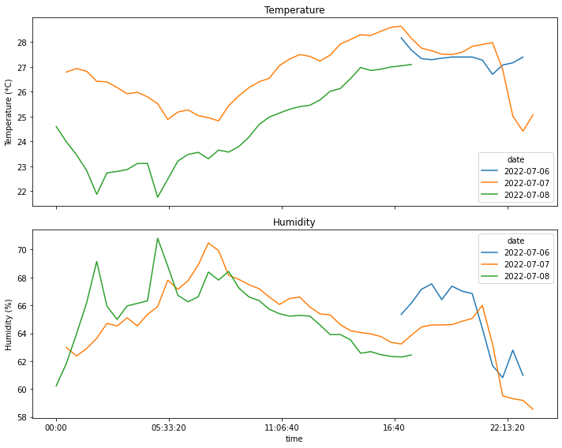

```python
fig, axs = plt.subplots(2,1, sharex=True, figsize=(10, 8))
df_pivot=df_resampled.pivot(index='time', columns='date')
a=df_pivot['temperature'].plot(title='Temperature', ylabel='Temperature (*C)', ax=axs[0], legend=True)

df_pivot=df_resampled.pivot(index='time', columns='date')
df_pivot['humidity'].plot(ax=axs[1], title='Humidity', ylabel='Humidity (%)', legend=True)

# plt.legend([a.lines])
plt.tight_layout()
plt.savefig('temp-humid-bedroom.png', transparent=False, facecolor='white')
```

### Finding the daily extremes

```python
# Simple dictionary for formatting the unit of measurement that will be printed
d_form = {'temperature': '*C', 'humidity': '%'}
```

```python
# Grouping by day
for idx, day_g in df_resampled.groupby('date'):
    print(f'Date: {idx}')

#     Maximum
#     idxmax returns the position of the maximum value
    aggr_i = day_g[['temperature', 'humidity']].aggregate(pd.Series.idxmax)
    aggr_m = day_g[['temperature', 'humidity']].aggregate(pd.Series.max)
#     Putting the values together for pretty printing
    df_t=pd.concat([aggr_i, aggr_m], axis=1)
    for i, val in df_t.iterrows():
        print(f'Max {i:>12} = {val[1]:.1f} {d_form[i]:>2} at {val[0].time()}')

#     Minimum
#     idxmax returns the position of the maximum value
    aggr_i = day_g[['temperature', 'humidity']].aggregate(pd.Series.idxmin)
    aggr_m = day_g[['temperature', 'humidity']].aggregate(pd.Series.min)
#     Putting the values together for pretty printing
    df_t=pd.concat([aggr_i, aggr_m], axis=1)
    for i, val in df_t.iterrows():
        print(f'Min {i:>12} = {val[1]:.1f} {d_form[i]:>2} at {val[0].time()}')
```

```
Date: 2022-07-06
Max  temperature = 28.2 *C at 17:00:00
Max     humidity = 67.5  % at 18:30:00
Min  temperature = 26.7 *C at 21:30:00
Min     humidity = 60.8  % at 22:00:00
Date: 2022-07-07
Max  temperature = 28.6 *C at 17:00:00
Max     humidity = 70.5  % at 07:30:00
Min  temperature = 24.4 *C at 23:00:00
Min     humidity = 58.5  % at 23:30:00
Date: 2022-07-08
Max  temperature = 27.1 *C at 17:30:00
Max     humidity = 70.8  % at 05:00:00
Min  temperature = 21.7 *C at 05:00:00
Min     humidity = 60.2  % at 00:00:00
```

## Part 4: Bonus section - Other (unsuccessful) attempts

In this section I'm gathering some additional methods I tried while working on the points shown above. I'm adding these both as a note to myself of what *doesn't work*, and for readers to see what can happen while trying stuff out.

From my understanding, part of the reason why these methods did not work quite as well as I hoped is due to the fact that I'm working with datetime objects, rather than "regular" indexing. This results in some funky behavior in some cases.

### Plotting struggles

The [pandas.DataFrame.melt](https://pandas.pydata.org/pandas-docs/stable/reference/api/pandas.melt.html#pandas.melt) function allows to obtain a "long form" version of a dataframe that pivots around some columns, while keeping other columns as variables. This can be extremely useful for plotting different variables on the same plot using libraries such as `seaborn`, which is what I will be trying in a moment.

```python
df_melted = df_resampled.melt(id_vars=['time', 'date'], value_vars=['temperature'])
df_melted['time'] = df_melted['time'].apply(datetime.time.isoformat)
display(df_melted)

# df_melted = df_melted.sort_values(['date', 'time'])
```

|  | time | date | variable | value |
| --- | --- | --- | --- | --- |
| 0 | 14:30:00 | 2022-07-13 | temperature | 31.266667 |
| 1 | 15:00:00 | 2022-07-13 | temperature | 32.048214 |
| 2 | 15:30:00 | 2022-07-13 | temperature | 32.547368 |
| 3 | 16:00:00 | 2022-07-13 | temperature | 32.926316 |
| 4 | 16:30:00 | 2022-07-13 | temperature | 33.198245 |
| ... | ... | ... | ... | ... |
| 147 | 16:00:00 | 2022-07-16 | temperature | 35.548214 |
| 148 | 16:30:00 | 2022-07-16 | temperature | 35.810526 |
| 149 | 17:00:00 | 2022-07-16 | temperature | 35.903573 |
| 150 | 17:30:00 | 2022-07-16 | temperature | 35.987719 |
| 151 | 18:00:00 | 2022-07-16 | temperature | 36.000000 |

152 rows × 4 columns

A "melted" dataframe can be plotted fairly easily using a command such as the one below. Besides the x- and y-axes, it is possible to distinguish the lines by hue (in this case, different colors for different dates) and by style (different line style for different variables). Here, it does not make a lot of sense to plot humidity and temperature in the same plot, but it is useful for the sake of the example.

Something else to note in the plot below is that the x-axis starts at 14:30, then continues for 24 hours until 14:00 the next day: this is due to the fact that the data captured by the log is incomplete for the day of 2022-07-13. After searching around for a while, I wasn't able to reset the ticks on the x-axis to make them work properly, so I had to look for some workarounds.

Indeed, the current plot shows a pretty major inconsistency at 0:00, which is when the date shifts from July 13th to July 14th, which is also why the orange line "jumps" below and seems to be a continuation of the blue line: this is exactly what that is!

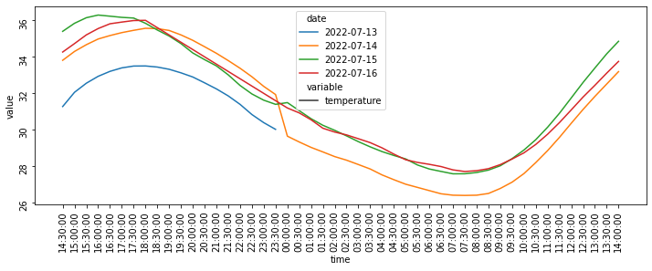

```python
fig = plt.figure(figsize=(12,4))
ax = sns.lineplot(data = df_melted, x='time', y='value', hue='date', style='variable')
ax.tick_params(rotation=90)
```

It is possible to build a plot by using the full `datetime` object, rather than splitting by day, and the result is shown below:

|  | datetime | variable | value |
| --- | --- | --- | --- |
| 0 | 2022-07-13 14:30:00 | temperature | 31.266667 |
| 1 | 2022-07-13 15:00:00 | temperature | 32.048214 |
| 2 | 2022-07-13 15:30:00 | temperature | 32.547368 |
| 3 | 2022-07-13 16:00:00 | temperature | 32.926316 |
| 4 | 2022-07-13 16:30:00 | temperature | 33.198245 |
| ... | ... | ... | ... |
| 147 | 2022-07-16 16:00:00 | temperature | 35.548214 |
| 148 | 2022-07-16 16:30:00 | temperature | 35.810526 |
| 149 | 2022-07-16 17:00:00 | temperature | 35.903573 |
| 150 | 2022-07-16 17:30:00 | temperature | 35.987719 |
| 151 | 2022-07-16 18:00:00 | temperature | 36.000000 |

152 rows × 3 columns

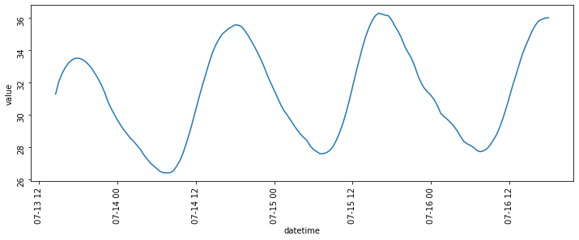

```python
df_melted = df_resampled.reset_index().melt(id_vars=['datetime'], value_vars=['temperature'])
display(df_melted)

fig = plt.figure(figsize=(12,4))
ax = sns.lineplot(data = df_melted, x='datetime', y='value')
ax.tick_params(rotation=90)
```

Now, this plot looks much clearer, however it's not exactly what I wanted. For this reason, I decided to get rid of the offending data series (i.e. the incomplete series of readings from the first day) and plot the data for the remaining days. This isn't really the best way of doing it, which is why I went for the solution in the first section of this post, but it gets the job done at least.

So, now my objective is selecting only the readings that start after the first day has ended, which can be done using either one of the two commands below, whose output is exactly the same.

`df_resampled.index` returns the index of the dataframe, which is in datetime format: this allows to compare it with a different datetime object that I am declaring (either `fromisoformat(...)` or `date(...)`). The comparison allows to find the datetime indices that occur after the given value, and keep only those.

```python
df_1 =df_resampled.loc[df_resampled.index >= datetime.datetime.fromisoformat('2022-07-14 00:00:00')]

df_2 =df_resampled.loc[df_resampled.index.date > datetime.date(2022, 7,13)]

# Checking that the two indices are equal
all(df_1.index == df_2.index)
```

```
True
```

Now that there is a cleaner dataframe to plot, the usual `lineplot` function can be used to prepare the temperature and humidity comparisons. |

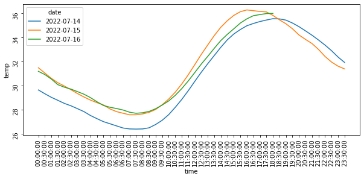

```python
df_melted = df_1.melt(id_vars=['time', 'date'], value_vars=['temperature'], value_name='temp')
df_melted['time'] = df_melted['time'].apply(datetime.time.isoformat)
df_melted = df_melted.sort_values(['date', 'time'])

fig = plt.figure(figsize=(10,4))
ax = sns.lineplot(data = df_melted, x='time', y='temp', hue='date')
ax.tick_params(rotation=90)
```

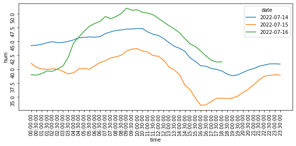

```python
df_melted = df_1.melt(id_vars=['time', 'date'], value_vars=['humidity'], value_name='hum')
df_melted['time'] = df_melted['time'].apply(datetime.time.isoformat)
df_melted = df_melted.sort_values(['date', 'time'])

fig = plt.figure(figsize=(10,4))
ax = sns.lineplot(data = df_melted, x='time', y='hum', hue='date')
ax.tick_params(rotation=90)
```

### Extracting extremes

After splitting the readings on a day-by-day basis using `pivot`, I looked for a way of getting the extremes using the same table. Turns out, this was far more complex than I thought, especially for printing them in an easy-to-read way.

Let's start by taking a look at `df_pivot` again:

```python
display(df_pivot.head())
```

| date time | temperature 2022-07-13 | temperature 2022-07-14 | temperature 2022-07-15 | temperature 2022-07-16 | humidity 2022-07-13 | humidity 2022-07-14 | humidity 2022-07-15 | humidity 2022-07-16 |
| --- | --- | --- | --- | --- | --- | --- | --- | --- |
| 00:00:00 | NaN | 29.640351 | 31.483636 | 31.187500 | NaN | 44.256141 | 41.012727 | 38.969643 |
| 00:30:00 | NaN | 29.321428 | 31.041071 | 30.917544 | NaN | 44.341071 | 40.332143 | 38.903509 |
| 01:00:00 | NaN | 29.025000 | 30.600000 | 30.540741 | NaN | 44.517857 | 40.024561 | 39.196297 |
| 01:30:00 | NaN | 28.775000 | 30.238182 | 30.076786 | NaN | 44.776786 | 39.936363 | 39.655357 |
| 02:00:00 | NaN | 28.519298 | 29.961403 | 29.866071 | NaN | 44.966667 | 40.045614 | 39.594642 |

This dataframe has a two-level header, with one half of the column covering the temperature on different days, and the other half recording humidity in the same periods of time. The index is a timeseries (not a datetime anymore, since the date is recorded in the columns).

```python
# Extracting the extremes and saving them in dataframes
val_idxmax=df_pivot[['temperature', 'humidity']].apply(pd.Series.idxmax)
val_max=df_pivot[['temperature', 'humidity']].apply(pd.Series.max)
```

```python
# Concatenating dataframes
df_concat = pd.concat([val_idxmax, val_max],  axis=1).reset_index().pivot(index='date', columns='level_0')
df_concat
```

| level_0 date | 0 humidity | 0 temperature | 1 humidity | 1 temperature |
| --- | --- | --- | --- | --- |
| 2022-07-13 | 14:30:00 | 18:00:00 | 49.774510 | 33.494737 |
| 2022-07-14 | 10:30:00 | 18:00:00 | 47.358182 | 35.562499 |
| 2022-07-15 | 10:00:00 | 16:00:00 | 43.696364 | 36.289285 |
| 2022-07-16 | 09:00:00 | 18:00:00 | 51.060715 | 36.000000 |

The result above kind of works, but is not very understandable: on the left, we have the *time at which the extreme was measured* and on the right we have the actual measured value.

It would be nicer to have a format similar to the original `df_pivot`, with temperature and humidity on top and the two variables `timeat` and `measured value` below. This can be done using a `MultiIndex`, which in this case I am building with the function `.from_product`. This function executes the cartesian product of the iterables passed as inputs and produces a MultiIndex object where each iterable represents a level in the multiindex.

```python
mi = pd.MultiIndex.from_product([['humidity', 'temperature'], ['timeat', 'value']])
mi
```

```
MultiIndex([(   'humidity', 'timeat'),
            (   'humidity',  'value'),
            ('temperature', 'timeat'),
            ('temperature',  'value')],
           )
```

At this point, I was looking for a way of massaging the columns and the index in order to make them match the multiindex, and this is what I came up with. Pretty ugly, but it works.

For each row in `df_concat`, I select the two columns of the multiindex (`timeat` and `value`, with labels 0 and 1 respectively), and then the specific variable (either humidity or temperature), so that the content of the list is:

```
[row[timeat][humidity], row[value, humidity], row[timeat][temperature], row[value][temperature]]
```

Finally, I add the index (i.e. the date) to the list, then I build the dataframe starting from those records. In the new dataframe, the index is then set to use the `date` column added to the list.

This is one way of printing the values, however I later realized that this makes actual pretty printing far more difficult, and the entire process thus far was quite clunky and "unpythonic", which is why I decided to something else.

```python
rows=[]
for idx, row in df_concat.iterrows():
    t = [row[i_][variable]  for variable in ['humidity', 'temperature'] for i_ in [0,1] ]
    rows.append([idx] + t)
```

```python
df_new = pd.DataFrame.from_records(rows)
df_new=df_new.set_index(0)
df_new.index.rename('date', inplace=True)
df_new.columns = mi
df_new
```

| date | humidity timeat | humidity value | temperature timeat | temperature value |
| --- | --- | --- | --- | --- |
| 2022-07-13 | 14:30:00 | 49.774510 | 18:00:00 | 33.494737 |
| 2022-07-14 | 10:30:00 | 47.358182 | 18:00:00 | 35.562499 |
| 2022-07-15 | 10:00:00 | 43.696364 | 16:00:00 | 36.289285 |
| 2022-07-16 | 09:00:00 | 51.060715 | 18:00:00 | 36.000000 |